# Final notebook

#### RWS Group 3

- Janine Timmerman - 4831578
- Honghao Zhao - 5735289
- Zhaoyu Yan - 5844940
- Syakal Hammas Kh Hujaemi - 5690021
- Yining Chen - 5722896

**Important information**

This notebook is the final notebook of RWS group 3. This notebook will take you through our process and shows the final results and conclusions. To keep this notebook clear and not too cluttered, not all the details will be presented in this notebook. Each section will refer to other notebooks if needed to show the full code and process.

This notebook and all other notebooks important for understanding the process will be available as a .ipynb file which can be run (altough it might take a lot of time), and a html file for easy viewing. All the html version of the notebooks can be found in the folder: **Notebooks_html**.

The backlog diary can be found in github in the wiki.

The dashboard can be accessed with the following link: https://rws-group3-48o79awm3zv6cbmgpeaj2d.streamlit.app/ (Loading the dashboard should not take more than 1 or 2 minutes. We've noticed it doesn't work (quickly) on all computers. Otherwise you could try a different browser/ pc if possible or watch the demo we provide: https://drive.google.com/file/d/1FeXwyoFK5YSuKzCb2jsGqc8d6DQ0hH00/view?usp=sharing The video shows the whole dashboard, but doesn't leave enough time to read everything, so feel free to pause the video if needed.)

Be aware, some code cells will take a lot of time to run! (So don't run everything)

## 1. Introduction

Each day many incidents happen on the road network of the Netherlands. To minimize the consequences on other traffic, road inspectors are send to the locations of the incidents. To ensure good and safe traffic flow, it is important that the road inspectors reach the locations as fast as possible. For this the road inspectors need to be stationed at efficient places so all incidents locations can be reached as far as possible. Currently, the average travel time of a road inspector to an incident is 18 minutes. The goal of this assignment is to find locations to get a travel time lower than 18 minutes.

This gives the following research question:

**What are the optimum locations for road inspectors to reach incidents as fast as possible?**

To help answer the question, there are several subquestions

- What are the best optimisation methods to locate the road inspectors to reach the incidents?
- What kind of different scenarios could be classified? (e.g. peak hour situation)
- How many inspectors should be introduced to the network in total to ensure that each incident has at least one inspector?

The remainder of this notebook will show the locations of inspectors we found and the process that brought us there. First, the data of the incidents is filtered and analysed. After that, data is collected about the speed and intensities of the road network, which is used ot determine the speed and travel times on each road section. After that the different algorithms are presented. The results of these algorithms are then validated and finally, the result and conclusions are shown.

## 2. Importing modules

In this project, many different python modules and libraries were used to make our code more efficient and to showcase the visualizations. There modules are imported in this section.

If it is not possible to run the following codeblock (and you want to): you can install the missing modules using

```
    pip install "NAME"
```

```python
# Calculations
import numpy as np
import numpy_indexed as npi
import math

import pandas as pd
import geopandas as gpd

from scipy import spatial

from sklearn.cluster import DBSCAN
from sklearn.cluster import KMeans
from collections import namedtuple

import networkx as nx
from geopy.distance import geodesic

import pyproj
import random
import math

# Visualization
import folium
from folium.plugins import HeatMap
from folium.plugins import MarkerCluster

import branca.colormap as cm
from distinctipy import distinctipy

%matplotlib inline
import matplotlib.pyplot as plt
import matplotlib.collections as mcoll

from mpl_toolkits.axes_grid1 import host_subplot
import mpl_toolkits.axisartist as AA

import json

# Others
import pickle
```

```python
# Functions for converting coordinates

def DutchRDtoWGS84(rdX, rdY):
    """ Convert DutchRD to WGS84
    """
    RD_MINIMUM_X = 11000
    RD_MAXIMUM_X = 280000
    RD_MINIMUM_Y = 300000
    RD_MAXIMUM_Y = 630000
    if (rdX < RD_MINIMUM_X or rdX > RD_MAXIMUM_X
        or rdY < RD_MINIMUM_Y or rdY > RD_MAXIMUM_Y):
        resultNorth = -1
        resultEast = -1
        return resultNorth, resultEast
    # else
    dX = (rdX - 155000.0) / 100000.0
    dY = (rdY - 463000.0) / 100000.0
    k = [[3600 * 52.15517440, 3235.65389, -0.24750, -0.06550, 0.0],
        [-0.00738   ,   -0.00012,  0.0    ,  0.0    , 0.0],
        [-32.58297   ,   -0.84978, -0.01709, -0.00039, 0.0],
        [0.0       ,    0.0    ,  0.0    ,  0.0    , 0.0],
        [0.00530   ,    0.00033,  0.0    ,  0.0    , 0.0],
        [0.0       ,    0.0    ,  0.0    ,  0.0    , 0.0]]
    l = [[3600 * 5.38720621,    0.01199,  0.00022,  0.0    , 0.0],
        [5260.52916   ,  105.94684,  2.45656,  0.05594, 0.00128],
        [-0.00022   ,    0.0    ,  0.0    ,  0.0    , 0.0],
        [-0.81885   ,   -0.05607, -0.00256,  0.0    , 0.0],
        [0.0       ,    0.0    ,  0.0    ,  0.0    , 0.0],
        [0.00026   ,    0.0    ,  0.0    ,  0.0    , 0.0]]
    resultNorth = 0
    resultEast = 0
    powX = 1

    for p in range(6):
        powY = 1
        for q in range(5):
            resultNorth = resultNorth + k[p][q] * powX * powY / 3600.0
            resultEast = resultEast + l[p][q] * powX * powY / 3600.0
            powY = powY * dY
        powX = powX * dX
    return resultNorth, resultEast

def WGS84toDutchRD(wgs84East, wgs84North):
    # translated from Peter Knoppers's code

    # wgs84East: longtitude
    # wgs84North: latitude

    # Western boundary of the Dutch RD system. */
    WGS84_WEST_LIMIT = 3.2

    # Eastern boundary of the Dutch RD system. */
    WGS84_EAST_LIMIT = 7.3

    # Northern boundary of the Dutch RD system. */
    WGS84_SOUTH_LIMIT = 50.6

    # Southern boundary of the Dutch RD system. */
    WGS84_NORTH_LIMIT = 53.7

    if (wgs84North > WGS84_NORTH_LIMIT) or \
        (wgs84North < WGS84_SOUTH_LIMIT) or \
        (wgs84East < WGS84_WEST_LIMIT) or \
        (wgs84East > WGS84_EAST_LIMIT):
        resultX = -1
        resultY = -1
    else:
        r = [[155000.00, 190094.945,   -0.008, -32.391, 0.0],
            [-0.705, -11832.228,    0.0  ,   0.608, 0.0],
            [0.0  ,   -114.221,    0.0  ,   0.148, 0.0],
            [0.0  ,     -2.340,    0.0  ,   0.0  , 0.0],
            [0.0  ,      0.0  ,    0.0  ,   0.0  , 0.0]]
        s = [[463000.00 ,      0.433, 3638.893,   0.0  ,  0.092],
            [309056.544,     -0.032, -157.984,   0.0  , -0.054],
            [73.077,      0.0  ,   -6.439,   0.0  ,  0.0],
            [59.788,      0.0  ,    0.0  ,   0.0  ,  0.0],
            [0.0  ,      0.0  ,    0.0  ,   0.0  ,  0.0]]
        resultX = 0
        resultY = 0
        powNorth = 1
        dNorth = 0.36 * (wgs84North - 52.15517440)
        dEast = 0.36 * (wgs84East - 5.38720621)

        for p in range(5):
            powEast = 1
            for q in range(5):
                resultX = resultX + r[p][q] * powEast * powNorth
                resultY = resultY + s[p][q] * powEast * powNorth
                powEast = powEast * dEast
            powNorth = powNorth * dNorth
    return resultX, resultY

def calc_distance(line_wkt):
    line = ogr.CreateGeometryFromWkt(line_wkt)
    points = line.GetPoints()
    d = 0
    for p0, p1 in zip(points, points[1:]):
        d = d + geodesic(p0, p1).m
    return d
```

## 3. Analysis of incident data

This section will filter and analyse the incident data. After that the data is split for training the algorithms and validating the algorithms.

### 3.1 Filtering of the data

Define a function that can:

- Delete the incidents which are not occured on the high ways
- Delete the incidents which the values for road number is missing
- Change name of all roads 'hrb'
- Delete the incidents that are out of the border of the Netherlands

```python
# Define a function to filter data
def data_filter(data_input):
    data_input = incidents.dropna()
    data_input.loc[:,'road_number'] = data_input['road_number'].replace({'A12 hrb':'A12', 'A16 hrb':'A16', 'A2 hrb':'A2'})
    new_data = data_input[data_input['road_number'].str.startswith('A')]
    new_data.drop(new_data.loc[new_data['index'] == 183130].index, inplace=True)

    return new_data

# Read raw data from a csv file
incidents = pd.read_csv('Dashboard_data\incidents_data', sep=';')
incidents.columns = ['index', 'id', 'type', 'start_time','end_time', 'road_number','longitude','latitude']
incidents['start_time'] = pd.to_datetime(incidents['start_time'])
incidents['end_time'] = pd.to_datetime(incidents['end_time'])
incidents.head()

# Dataframe of filtered data
incidents_df = data_filter(incidents)
```

### 3.2 Analysis of incidents

To gain a deeper understanding of incidents data, it is necessary to conduct a prelimintary data analysis.

#### 3.2.1 Mark all incidents at the road network in heatmap

Firstly, there is need to have a macro-level understanding of the locations of all incients.Here all incidents are plotted at the heat map based on the longitude and langitude coordinates. In this way, it is easy to find the incident high-frequency area. Specicically, the number of incidents occuring on highways near Amsterdam and Rotterdam-Hague area is relatively high, which can be conclued that the probability there is higher thann other area, therefore, it is necessary to assign more inspector there.

For heatmap drawn, please see **'3.2 Incident heatmap.html'**

```python
def draw_incidents(filter_type, keyword):

    # Define a new map
    m = folium.Map(location=[52.399190, 4.893658])

    if filter_type == 'Incident_type':
        new_data = incidents_df.loc[incidents_df['type'] == keyword]
        # Extract the latitude and longitude as a list of lists
        heat_data = [[ row['latitude'], row['longitude']] for _, row in new_data.iterrows()]
        # Create a heatmap layer
        HeatMap(heat_data).add_to(m)
    return m

map_new = draw_incidents('Incident_type', 'accident')
map_new.save('3.2 Incident heatmap.html')
```

#### 3.2.2 Analysis of time periods when incidents occurs (starting time)

Secondly, all incident can be classified by occuring timw, here they are classfied by 5 time ranges, 0-5h(Midnight), 6-9h(morning peak hour), 10-14h(noon), 15-18h(evening peak hour), 19-23h(evening). Then the probability occuring different time range can be obatined. The probability result and bar chart can be shown in **'3.2.2 Probability of different time periods.csv'**

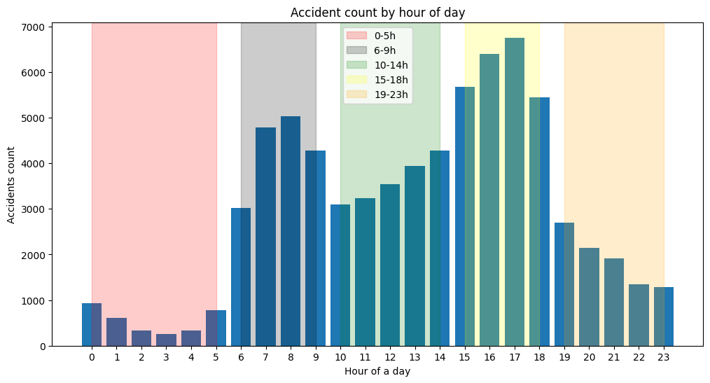

```python
incidents_df['hour_of_day'] = incidents_df['start_time'].apply(lambda x: x.hour)
hourly_counts = incidents_df.groupby('hour_of_day').size().reset_index(name='accident_count')

# Calculate the probability of time of a day for incident
pro_0_5h = hourly_counts['accident_count'][:6].sum() / hourly_counts['accident_count'].sum()
pro_6_9h = hourly_counts['accident_count'][6:10].sum() / hourly_counts['accident_count'].sum()
pro_10_14h = hourly_counts['accident_count'][10:15].sum() / hourly_counts['accident_count'].sum()
pro_15_18h =hourly_counts['accident_count'][15:19].sum() / hourly_counts['accident_count'].sum()
pro_19_23h = hourly_counts['accident_count'][19:].sum() / hourly_counts['accident_count'].sum()

result_data = {
    'Time Range': ['0-5 hours', '6-9 hours', '10-14 hours', '15-18 hours', '19-23 hours'],
    'Probability': [pro_0_5h, pro_6_9h, pro_10_14h, pro_15_18h, pro_19_23h]
}

pro_time = pd.DataFrame(result_data)
pro_time.to_csv('3.2.2 Probability of different time periods.csv')

# Next is the visualiztion of the result as bar chart
incidents_df['hour_of_day'] = incidents_df['start_time'].apply(lambda x: x.hour)
hourly_counts = incidents_df.groupby('hour_of_day').size().reset_index(name='accident_count')

plt.figure(figsize=(12, 6))
plt.bar(hourly_counts['hour_of_day'], hourly_counts['accident_count'])
plt.xlabel('Hour of a day')
plt.ylabel('Accidents count')
plt.title('Accident count by hour of day')
plt.xticks(hourly_counts['hour_of_day'])

plt.axvspan(0, 5, alpha=0.2, color='red', label='0-5h')
plt.axvspan(6, 9, alpha=0.2, color='black', label='6-9h')
plt.axvspan(10, 14, alpha=0.2, color='green', label='10-14h')
plt.axvspan(15, 18, alpha=0.2, color='yellow', label='15-18h')
plt.axvspan(19, 23, alpha=0.2, color='orange', label='19-23h')
plt.legend()
# plt.show() The figure can be show in the same csv file ''3.2.2 Probability of different time periods.csv''
```

#### 3.2.3 Analysis of day of week when incidents occurs

Additionally, the probabilites of incident occuring different day if a week are also shown. The result can be shown in **'3.2.3 Probability at different days of a week'**

```python
incidents_df['day of week'] = incidents_df ['start_time'].dt.dayofweek
weekly_count = incidents_df['day of week'].value_counts(normalize=True)
day_mapping = {
    0: 'Monday',
    1: 'Tuesday',
    2: 'Wednesday',
    3: 'Thursday',
    4: 'Friday',
    5: 'Saturday',
    6: 'Sunday'
}
weekly_count.index = weekly_count.index.map(day_mapping)

pro_weekly = pd.DataFrame({
    'Day of Week': weekly_count.index,
    'Probability': weekly_count.values
})
pro_weekly.to_csv('3.2.3 Probability at different days of a week',index=False)
```

#### 3.2.4 Analysis of accident frequency and duration time in each highway

This part shows probability of incidents occuring on various highways, along with the corresponding duration times for these incidents.

For result, see **3.2.4 Road number count and duration.csv**

```python
# count the number of accidents in each road
accidents_number = incidents_df.groupby('road_number').size()
accidents_df = accidents_number.reset_index()
accidents_df.columns = ['road_number', 'accidents_number']

# count the average lasting time for each road
incidents_df['Duration_time'] = (incidents_df['end_time'] - incidents_df['start_time']).dt.total_seconds() / 60
average_duration_by_road = incidents_df.groupby('road_number')['Duration_time'].mean()
duration_df = average_duration_by_road.reset_index()
duration_df.columns = ['road_number', 'average_duration']

# Mix them and create the new dataframe
road_number_counts = pd.merge(accidents_df, duration_df, on='road_number', how='left')
road_number_counts.to_csv('3.2.4 Road number count and duration.csv', index=False)
```

### 3.3 Splitting training and validation data

Here all incident data is classified as two parts: training data(80%) and validation data(20%).

```python
data = incidents_df[['latitude','longitude']].values
num_samples = len(data)
num_samples_keep = int(0.8*num_samples)

#Random distruption data
np.random.shuffle(data)
selected_data = data[:num_samples_keep] # Here we name the training data as seleced_data
remaining_data = data[num_samples_keep:] # Here we name the validation data as remaining data
```

## 4. Travel times

Each algorithm will need to calculate the travel times between inspectors and incidents to find the optimal locations of the road inspectors. All the tools needed to calculate these travel times are given in this section.

### 4.1 Speed data on road sections

First the speed on each road section of the network is determined. For the full calcutions please take a look at the notebook **speed_network_data.html** or the .ipynb version. This section will only show the results.

First there is the following dataframe. It has been obtained by combining the given shapefiles, open source wkd ("Wegkenmerkendatabase") data about the maximum speed and INWEVA ("INtensiteit WEgVAkken") data which gives traffic intensities on road sections. There was some missing data, which has been filled with data from adjacent road sections.

```python
road_section_data = pd.read_csv('speed_data', sep=';')
road_section_data.head()
```

|  | Road_section_id | Road_number | Section_length_(m) | geometry | Max_speed | coords | Min_travel_time_[s] | No_of_lanes | Morning_peak_[veh/h] | Evening_peak_[veh/h] | Average_peak_[veh/h] | Peak_speed_km/h | Peak_travel_time_[s] |
| --- | --- | --- | --- | --- | --- | --- | --- | --- | --- | --- | --- | --- | --- |
| 0 | 235252052 | A15 | 225.0 | LINESTRING (117613.756 426301.388, 117622.09 4... | 130.0 | [(117613.756, 426301.388), (117622.09, 426302.... | 6.2 | 1.0 | 288.0 | 270.0 | 279.0 | 107.7 | 7.5 |
| 1 | 463451006 | A37 | 209.0 | LINESTRING (231708.389 525975.794, 231713.477 ... | 130.0 | [(231708.389, 525975.794), (231713.477, 525976... | 5.8 | 1.0 | 242.0 | 504.0 | 373.0 | 107.2 | 7.0 |
| 2 | 398527014 | A7 | 125.0 | LINESTRING (199413.84100000001 563825.915, 199... | 130.0 | [(199413.84100000001, 563825.915), (199429.067... | 3.5 | 1.0 | 88.0 | 132.0 | 110.0 | 108.6 | 4.1 |
| 3 | 181193022 | A17 | 350.0 | LINESTRING (90581.131 396850.172, 90598.799 39... | 130.0 | [(90581.131, 396850.172), (90598.799, 396873.0... | 9.7 | 1.0 | 134.0 | 318.0 | 226.0 | 108.0 | 11.7 |
| 4 | 205343018 | A44 | 149.0 | LINESTRING (102810.117 471704.421, 102817 4717... | 120.0 | [(102810.117, 471704.421), (102817.0, 471705.0... | 4.5 | 1.0 | 216.0 | 312.0 | 264.0 | 107.1 | 5.0 |

The travel times on each road section have been determined for optimal conditions, which assumed that the road inspector is driving at the maximum speed (in 2019) and for peak hour conditions. The peak hour conditions were estimated using a data-driven function using data like the intensity on the road, time of the day, no. of lanes, etc. (See the speed_network_data notebook for all details)

### 4.2 NetworkX graph creation

As stated above, there was some missing data about e.g. the maximum speed on the road sections. This data was filled by looking at the maximum speed of adjacent road sections. This was done by creating a directed NetworkX graph.

Beneath, you see the code that was used to create the graph. The start and end point of each edge was added as a node to the network. The road section was then added as an edge between the two nodes. Several attributes were added to the edges to keep track of the properties of the road section.

```
G = nx.DiGraph()
nx.set_edge_attributes(G, 0, 'Max_speed')
nx.set_edge_attributes(G, 0, 'Road_number')
nx.set_edge_attributes(G, 0, 'Road_section_id')

for i in range(len(merged_network)):

    # Get the first and last node from each road section
    start = merged_network.geometry[i].coords[0]
    end = merged_network.geometry[i].coords[-1]

    # Add the nodes and edges to the graph
    G.add_node(start)
    G.add_node(end)

    G.add_edge(start, end, geometry=merged_network.geometry[i])

    # Add different attributes from the dataframe to the graph
    G.edges[(start, end)]['Max_speed'] = merged_network.Max_speed[i]
    G.edges[(start, end)]['Road_number'] = merged_network.Road_number[i]
    G.edges[(start, end)]['Road_section_id'] = merged_network.Road_section_id[i]
```

Because of NetworkX functions, it was easy to get adjecent edges tp use for filling in missing data. Later on, more attributes were added to the network as more was calculated.

```python
# Load networkX graph
G = pickle.load(open('NetworkX_graph.pickle', 'rb'))

# Show edge attributes of random edge
G.edges[list(G.edges)[0]]
```

```
{'geometry': <LINESTRING (117613.756 426301.388, 117622.09 426302.275, 117634.941 426306....>,
 'Max_speed': 130.0,
 'Road_number': 'A15',
 'Road_section_id': 235252052,
 'Min_travel_time_[s]': 6.2,
 'Peak_travel_time_[s]': 7.5,
 'Peak_speed': 107.7}
```

As you can see, the graph contains speeds for optimal and peak hour conditions, road number, road section id and the travel times.

However, when trying to find the path between shortest nodes, it was quickly concluded that this graph is not yet strongly connected. In other words, it was not possible to find a path between each two nodes.

```python
nx.is_strongly_connected(G)
```

```
False
```

The next step was to make the graph fully connected, so it is possible to calculate the travel time between all nodes. The full process of connecting all nodes can be found in the following notebook: **connect_networkX_graph.html** or the .ipynb version.

To connect the full network, two different algorithms were used.

First, there was looped over each node in graph G to check if the node missed an incoming or outgoing node. If one of those were missing, the algorithms would loop over the nearest nodes and check if it complied to several constraints. If so, the nodes were connected. Using this method around 1800 edges were added to the network and all nodes had at least an incoming and an outgoing edge. (So it is possible to reach and leave the node).

After that, the network was still not strongly connected and a second algorithm was used. There were still over 400 strongly connected components (instead of 1). The second algorithm looped over all strongly connected components and would connect each component to the nearest component. This algorithm used less constraints and the added edges might be less accurate.

Still, after the second algorithm, the whole network was strongly connected.

```python
# Load networkX graph
G = pickle.load(open('NetworkX_graph_new.pickle', 'rb'))

# Check if new network is strongly connected
nx.is_strongly_connected(G)
```

```
True
```

Now, there only needs to be checked if edges that were added to the network seem realistic.

```python
# Get info about when the edge was added (or if it already existed)
new_edge_val = np.array(list(nx.get_edge_attributes(G, 'New_edge').values()))
new_edge_key = np.array(list(nx.get_edge_attributes(G, 'New_edge').keys()))
```

```python
edges_sorted = []

for i in range(3):
    edges_sorted.append(new_edge_key[new_edge_val == i])
```

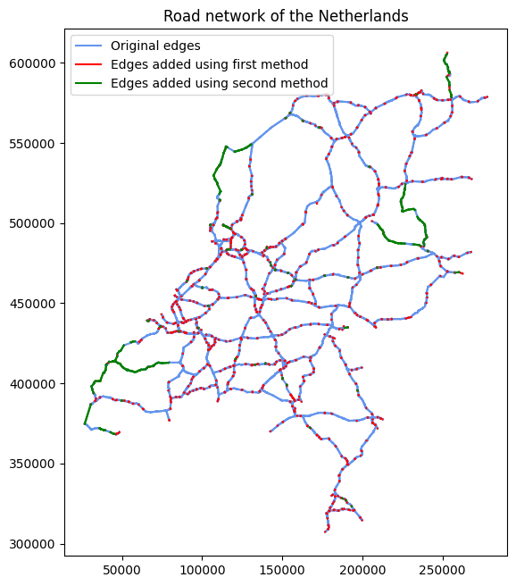

```python
# Create figure
fig, ax = plt.subplots()

ax.set_title('Road network of the Netherlands')

# Give axis equal scale
fig.set_figheight(9)
ax = plt.gca()
ax.set_aspect('equal', adjustable='box')

# Define colors and labels
colors = ['cornflowerblue', 'red', 'green']
labels = ['Original edges', 'Edges added using first method',
          'Edges added using second method']

# Plot the different colored edges in the road network
for i in range(3):
    ax.plot([],[], color=colors[i], label=labels[i])

    for j in range(len(edges_sorted[i])):
        ax.plot(edges_sorted[i][j,:,0],
                edges_sorted[i][j,:,1], color=colors[i])



plt.legend(loc='upper left');
```

As you can see, all the edges added in the first iteration seem to connect small stretches between nodes.'

The green edges are larger, especially around several roads in Zeeland and Drenthe. This is due to the fact these are more regional roads and were given in the shapefile as a single lane, instead of several lanes as was done for the highways. This means according to the networkX graph, the road could only be driven in one direction and that had to be fixed.

### 4.3 Travel time between nodes

Now the network graph is finished, a function must be defined to calculate travel times. This function is used in all the algorithms to calculate the travel times. For the full notebook of this function see **travel_time_func.html** or the .ipynb version. This notebook also shows several visualizations of shortest paths between nodes and some visualizations about the areas an inspector serves.

```python
# travel_time function
def travel_time_func(point1, point2, time='min'):
    """This function uses the information given in network X to return the travel time between two points.
        point1 and point2 should be tuples with the coordinates in longitude, latitude.
        if time = 'peak', the peak travel time is used. In all other cases the minimum travel time is used."""

    # Determine which travel times to use
    if time == 'peak':
        time_string = 'Peak_travel_time_[s]'
    else:
        time_string = 'Min_travel_time_[s]'

    # Change points to Dutch system
    p1_x, p1_y = WGS84toDutchRD(point1[0], point1[1]) # inspector
    p2_x, p2_y = WGS84toDutchRD(point2[0], point2[1]) # incident

    # Create numpy matrix from nodes
    A = np.array(list(G.nodes()))

    # Get node closest to each point
    dist_node1, index_node1 = spatial.KDTree(A).query([p1_x, p1_y])
    node1 = (A[index_node1][0], A[index_node1][1])

    dist_node2, index_node2 = spatial.KDTree(A).query([p2_x, p2_y])
    node2 = (A[index_node2][0], A[index_node2][1])

    # Get shortest path between nodes
    route = nx.shortest_path(G, node1, node2, time_string)
    travel_time = nx.shortest_path_length(G, node1, node2, time_string)

    return route, travel_time
```

This function needs as input the WGS84 coordinates of the inspector (origin) and the incident (destination). It then searches for the node closest to the inspector and the node closest to the incident. After that, the shortest path between those 2 nodes is calculated based, using the travel time in optimal conditions, or if you prefer, the travel time using peak hour conditions.

Because the distances between 2 nodes are often short (most of the time it takes only a few seconds to travel between two adjacent nodes), the distance between the actual locations and the nodes is neglected. In the aforementioned notebook, the travel times between the node and each incident was calculated (assuming a speed of 120 km/h and eucledian distance), and on average it took 9.1 seconds, while the median was 3.4 seconds. This is not much time when looking at an average travel time of 18 minutes.

(There are several larger outliers however, where the distance between a node and incident are up to 6 minutes. This makes this method less accurate, because the actual travel time between the incident and the inspector could be 6 minutes longer or shorter. But because the average travel time is still many times lower, those outliers will be neglected.)

## 5. Algorithms for inspector locations

In this section the 4 different algorithms are presented.

### 5.1 Objective functions

The objective function is to compare the number of road inspectors within a time limit, given a fixed mean travel time, the less the road inspectors, the better the method is. First the k-means clustering by distance method is used to calculte the optimal number of inspectors, while still mainting the average travel time of 18 minutes. After that, the other algorithms will determine the optimal locations to find the shortest average travel time based on the number of inspectors from the first method. This way all optimization methods can be easily compared with each other because they determine the optimal locations for the same number of inspectors

### 5.2 K-means clustering by distance

The algorithm of K-means clustering by distance uses the incidents data and the network information as the input.

The following steps explain how this method work:

(3) Calculate the mean travel time of this scenario, check if the mean travel time is within the time limit. If so, minus one to the number of clusters (a.k.a the number of road inspectors).

(4) Repeat step 1 to step 3 until the mean travel time exceeds the time limit. Then the scenario before the scenario in which the iteration stop is considered as the optimal scenario.

The result of this algorithm is saved to a .html file named "min_inspector_map.html", a single run of this algorithm could take around 5 hours. For further studying purpose, the travel time in peak hours are also used to find the optimal locations of road inspectors, the result is also saved to a .html file. The result of locations of road inspectors during peak hours can be refered in 'peak_inspector_map'.

```python
# Create a list of converted coordinates
converted_coordinates = [DutchRDtoWGS84(rd_x, rd_y) for (rd_x, rd_y) in list(G.nodes)]

# Create a Pandas DataFrame from the converted coordinates
node_df = pd.DataFrame(converted_coordinates, columns=['Latitude', 'Longitude'])

# Display the DataFrame
node_df

# Define a data structure to store kd-tree nodes
KdNode = namedtuple("KdNode", "point left right")

# Build k-d tree
def kdtree(point_list, depth=0):

    if not point_list:
        return None

    k = 2  # 2-dimensional space
    axis = depth % k

    point_list.sort(key=lambda x: x[axis])
    median = len(point_list) // 2

    return KdNode(
        point=point_list[median],
        left=kdtree(point_list[:median], depth + 1),
        right=kdtree(point_list[median + 1 :], depth + 1),
    )


# Find the closest point
def closest_node(root, target, depth=0, best=None):
    if root is None:
        return best

    k = 2  # 2-dimensional space
    axis = depth % k

    next_best = None
    next_branch = None

    if best is None or (
        point_distance(root.point, target) < point_distance(best, target)
    ):
        next_best = root.point
    else:
        next_best = best

    if target[axis] < root.point[axis]:
        next_branch = root.left
    else:
        next_branch = root.right

    return closest_node(next_branch, target, depth + 1, next_best)


# Calculate the distance between points
def point_distance(point1, point2):
    return math.sqrt((point1[0] - point2[0]) ** 2 + (point1[1] - point2[1]) ** 2)


# Extract points from dataframe
points = [(row[0], row[1]) for index, row in node_df.iterrows()]
tree = kdtree(points)


def clustering_opt(k_value, data, target_travel_time):
    # Create a K-Means clustering model
    kmeans = KMeans(n_clusters=k_value)

    # Fit the model to the latitude and longitude data
    locations = data[["latitude", "longitude"]].values
    kmeans.fit(locations)

    # Assign cluster labels to data points
    data["cluster"] = kmeans.labels_ + 1

    m = folium.Map(
        location=[np.mean(locations[:, 0]), np.mean(locations[:, 1])],
        zoom_start=8,
        zoom_control=False,
    )

    # Create a MarkerCluster layer for clustered data
    marker_cluster = MarkerCluster().add_to(m)

    # Create a dictionary to keep track of the event count in each cluster
    cluster_event_count = {}

    # Create an array to store node coordinates for each cluster
    cluster_coords = []

    # Initiate the longest travel time
    longest_travel_time = -1  # second

    # Initiate the total travel time
    total_travel_time = -1  # second

    # Initiate the point count
    point_count = 0

    # Add markers for clustering
    for cluster_label in range(1, k_value + 1):
        cluster_data = data[data["cluster"] == cluster_label]
        cluster_count = len(cluster_data)
        cluster_event_count[cluster_label] = cluster_count
        cluster_coords.append(cluster_data)

        for _, row in cluster_data.iterrows():
            popup_text = f"Cluster: {row['cluster']}<br>Type: {row['type']}<br>Index: {row['index']}"
            folium.Marker(
                [row["latitude"], row["longitude"]], icon=None, popup=popup_text
            ).add_to(marker_cluster)

    cluster_centers = kmeans.cluster_centers_
    ins_loc = [closest_node(tree, coord) for coord in cluster_centers]

    for i, center in enumerate(ins_loc):
        cluster_label = i + 1
        center_popup_text = f"Cluster_No.{i + 1}<br>Event_Count:{cluster_event_count[cluster_label]} \
            <br>Coordinate:{[format(center[0], '3f'), format(center[1], '.3f')]}"

        # Use ClickForMarker to display the event count when clicking the cluster center
        folium.ClickForMarker(popup=center_popup_text).add_to(m)

        folium.Marker(
            [center[0], center[1]],
            icon=folium.Icon(color="red"),
            popup=center_popup_text,
        ).add_to(m)

    # Initialize a list to store time-related information
    time_data = []

    # Calculate and update the longest travel time in each cluster
    for i, center in enumerate(ins_loc):
        cluster_label = i + 1
        cluster_data = data[data["cluster"] == cluster_label]
        point1 = (ins_loc[i][1], ins_loc[i][0])

        for index, row in cluster_data.iterrows():
            point2 = (row["longitude"], row["latitude"])
            r, time_this = travel_time_func(point1, point2, time='min')
            total_travel_time += time_this

            if time_this > target_travel_time:
                point_count += 1

            # Store time-related information in the time_data list
            time_data.append(
                [
                    row["index"],
                    row["id"],
                    row["type"],
                    row["longitude"],
                    row["latitude"],
                    cluster_label,
                    time_this,
                ]
            )

    # Create a Pandas DataFrame to store time-related information
    time_df = pd.DataFrame(
        time_data,
        columns=[
            "index",
            "id",
            "type",
            "longitude",
            "latitude",
            "cluster",
            "time_this",
        ],
    )

    # Calculat the mean travel time
    incident_count = data.shape[0]
    mean_travel_time = total_travel_time / incident_count

    # Print the longest travel time of the scenario with specific number of inspectors
    print(f"The mean travel time is {mean_travel_time} seconds!")

    return m, ins_loc, mean_travel_time, point_count, time_df


def find_optimal(initial_k_value, target_travel_time):
    # The unit of travel time is second
    k_value = initial_k_value

    # Initialize the travel time
    flag = True

    # Iterate to find the optimal number
    while True:
        if flag == False:
            # Keep a record for the previous optimised results
            opt_clustered_map = clustered_map
            opt_inspector_locations = inspector_locations
            opt_mean_travel_time = mean_travel_time
            travel_times = time

        # Calculate the travel time and the clustered map
        (
            clustered_map,
            inspector_locations,
            mean_travel_time,
            point_count,
            time,
        ) = clustering_opt(k_value, incidents_df, target_travel_time)
        flag = False
        k_value -= 1
        if mean_travel_time > target_travel_time:
            break

    optimal_number = k_value + 1
    print(f"The optimal number of inspectors is {optimal_number}!\n")

    return (
        opt_clustered_map,
        opt_inspector_locations,
        opt_mean_travel_time,
        optimal_number,
        travel_times,
    )


# Use the function to calculate the optimal locations of road inspectors
(
    inspector_map,
    inspector_locations,
    opt_mean_travel_time,
    optimal_number,
    travel_times,
) = find_optimal(50, 1080)

# The result is saved to a .html file, a single run could take around 5 hours. Here the .html is read to illustarte the result.
# The codes below save the result to a .html file named "min_inspector_map.html"
inspector_map.save("min_inspector_map.html")
```

### 5.3 K-means clustering by travel time

This algorithm is simliar with the first algorithm, which also use K means method to cluster. The main difference is that we calculate the travel time as the criteria to cluster instead of using distance directly. The following step shows how algorithm works:

(1) Set the number of inspector is 47, which is same as the first algorthim.

(2) Intialize 47 cluster center by using traditional K means cluster method (by distance)

(3) Set the criteria as 18 mins, and calculate travel time between all incidents within one cluster and corresponding the cluster center

(4) Determine the maximum of travel time for each cluster, if any travel time exceeds 18 minutes, all cluster center need to be relocated

(5) Iterate to find the location of cluster centers until no redrawing process existing

The location for optimal result is shown in **'JOEY.csv'**

```python
from sklearn.cluster import KMeans
from sklearn.neighbors import KDTree
import numpy as np
from scipy.spatial import cKDTree  # Using cKDTree from scipy
import pandas as pd

# Build KD Tree
def build_kd_tree(node_data):
    return cKDTree(node_data)

# Find the closest point
def closest_node(kdtree, target):
    _, nearest_node_index = kdtree.query(target, k=1)
    return kdtree.data[nearest_node_index]

# Custom K-means function
def custom_kmeans_with_travel_time(data, k, max_iterations=5):
    # Build KD Tree
    kdtree = build_kd_tree(node_data)

    # Initialize K-means
    kmeans = KMeans(n_clusters=k, max_iter=max_iterations, n_init=1, random_state=0)

    # Fit K-means to get initial cluster centers
    kmeans.fit(data)

    # Initialize cluster_centers with initial cluster centers
    cluster_centers = kmeans.cluster_centers_
    cluster_centers = cluster_centers[:, [1, 0]]

    max_travel_time = 18 * 60  # 18 minutes in seconds

    # Continue reassigning incidents until no reassignments are made (Here is the main difference from the first method!)
    reassignments_made = True
    while reassignments_made:
        reassignments_made = False
        for i in range(k):
            cluster_center = cluster_centers[i]
            cluster_incidents = data[kmeans.labels_ == i]
            cluster_incidents = cluster_incidents[:, [1, 0]]

            for incident in cluster_incidents:
                _, travel_time = travel_time_func(incident, cluster_center)
                if travel_time > max_travel_time:
                    # Find the nearest node using KD Tree
                    nearest_node = closest_node(kdtree, incident)

                    # Reassign the incident to the nearest cluster
                    cluster_centers[i] = nearest_node
                    reassignments_made = True
                    break

        print(f'cluster center {i} is {cluster_centers}')

    return kmeans.labels_, cluster_centers

# Use the new KD Tree library
k = 47
data = selected_data
node_data = node_df[['longitude', 'latitude']].values
cluster_labels, cluster_centers = custom_kmeans_with_travel_time(data, k, max_iterations=5)
```

### 5.4 Simulated annealing

The simulated annealing algorithm is applied to build a machine learning optimizer in this part. The explanations of the model are as follows:

- Goal:

  Try to find the optimal locations of inspectors on the network with a minmum average travel time from each accident point to the nearest inpector's location. The final output is saved as "results_simulated_annealing.csv"
- Input:

  (1) Possible locations of inspectors(the possible locations refer to all the nodes on NetworkX)

  (2) Filtered accident positions(in order to have a much more efficient model, the train set with 80% num of total accident points is filtered to give 100 clustering center of accidents, using K-means clustering by distance method)

  (3) travel time function(the function defined previously)

  (4) Cooling rate, initial temperature(they control the speed of convergence and thus the possiblity to avoid sub minimum point), max num of iterations
- Output:

  (1) Optimal distribution of 47 inspectors' locations
- Step:

  (1) Determine the 100 clustering centers of accidents using K-means clustering by distance method

  (2) Set values for cooling rate(constant), initial temperature(constant) and initial locations of inspectors(random)

  (3) Calculate the current result of average travel time

  (4) Change random num of current inspectors' locations to new points

  (5) Calculate the new result of average travel time

  (6) Based on the camparision of the 2 previous results with Metropolis Criterion:

  $$P_{\text{accept}} = \begin{cases} 1, & \text{if } \Delta E \leq 0 \\ e^{-\frac{\Delta E}{T}}, & \text{if } \Delta E > 0 \end{cases}$$

  (where E represents the difference between 2 results and T is current temperature) it is determined to what extent the new solution should be accepted.

  (7) Change the current temperature with the defined cooling rate

  (8) Go back to step (3) until iteration meets the max

```python
# Create a transformer for batch conversion
transformer = pyproj.Transformer.from_crs("EPSG:28992", "EPSG:4326", always_xy=True)

# Define the number of inspectors and accidents centers
num_inspectors = 47
num_accidents = 100

# Define the possible positions for inspectors
possible_inspectors = list(G.nodes)

# Use transformer.transform to convert the list of combined RD to WGS84
possible_inspectors = list(transformer.transform(*zip(*possible_inspectors)))
possible_inspectors = list(zip(*possible_inspectors))

# Initialize the initial solution with random positions for inspectors
initial_solution = random.sample(possible_inspectors, num_inspectors)

# Define the coordinates of the accidents
#(Notice that the accident_coordinates is given by the method of K-means clustering by distance, with k = 100)
accident_coordinates = inspector_locations
accident_coordinates = [(accident[1], accident[0]) for accident in accident_coordinates]

# Set the initial temperature, cooling rate, and max iterations for simulated annealing
initial_temperature = 200
cooling_rate = 0.8
max_iterations = 100
```

```python
# Define a function to compute the average travel time
def total_average_travel_time(inspector_coordinates, accident_coordinates):
    total_travel_time = 0

    for accident in accident_coordinates:
        nearest_inspector = min(inspector_coordinates, key=lambda inspector: travel_time_func(inspector, accident))
        travel_time = travel_time_func(nearest_inspector, accident)
        total_travel_time += travel_time

    return total_travel_time / len(accident_coordinates)

# Establish the simulated-annealing model
def simulated_annealing(initial_solution, initial_temperature, cooling_rate, max_iterations):
    current_solution = initial_solution
    current_temperature = initial_temperature
    best_solution = current_solution
    best_score = total_average_travel_time(current_solution, accident_coordinates)

    for iteration in range(max_iterations):
        neighbor_solution = current_solution.copy()
        # Randomly select inspectors and move them to new positions
        inspector_to_move = random.choice(range(47))
        new_position = random.choice(possible_inspectors)
        neighbor_solution[inspector_to_move] = new_position

        neighbor_score = total_average_travel_time(neighbor_solution, accident_coordinates)
        score_diff = neighbor_score - best_score

        if score_diff < 0 or random.random() < math.exp(-score_diff / current_temperature):
            current_solution = neighbor_solution
            best_score = neighbor_score
            if neighbor_score < best_score:
                best_solution = neighbor_solution

        current_temperature *= cooling_rate

        # Print the current average travel time in each iteration
        print(f"Iteration {iteration}: Average Travel Time = {best_score}")

    return best_solution, best_score
```

```python
# Run the simulated annealing algorithm
best_solution, best_score = simulated_annealing(initial_solution, initial_temperature, cooling_rate, max_iterations)

# The best_solution contains the optimal positions for inspectors
# The best_score is the total average travel time for that solution
```

```python
print(best_solution)
```

```python
# Create a csv file to save the result
import csv
csv_filename = "results_simulated_annealing.csv"

with open(csv_filename, 'w', newline='') as csvfile:
    csv_writer = csv.writer(csvfile)
    csv_writer.writerow(["Accident Coordinates", "Inspector Coordinates", "Travel Time"])

    for accident in accident_coordinates:
        nearest_inspector = min(best_solution, key=lambda inspector: travel_time_func(inspector, accident))
        travel_time = travel_time_func(nearest_inspector, accident)

        # Write the data to the CSV file
        csv_writer.writerow([accident, nearest_inspector, travel_time])

print(f"Data has been written to {csv_filename}")
```

```python
inspector_accident_travel_time = pd.read_csv('Dashboard_data\Optimization_results\sa_accidents_inspectors_travel_times.csv')
inspector_accident_travel_time
```

|  | Accident Coordinates | Inspector Coordinates | Travel Time |
| --- | --- | --- | --- |
| 0 | (5.427092464301113, 52.17510240540146) | (5.538709553205525, 52.164081566703956) | 991.195324 |
| 1 | (4.370861530958569, 51.90567808232686) | (4.418247764344501, 51.92434228043359) | 244.015587 |
| 2 | (6.205149171396056, 52.63933810770854) | (6.245961328725472, 52.42932030767067) | 757.204914 |
| 3 | (5.327958983222265, 51.37427012212052) | (5.152632662616089, 51.54482347257512) | 1692.261521 |
| 4 | (4.978740584600662, 52.34498520349354) | (4.9529142962967185, 52.301432080423936) | 296.921046 |
| ... | ... | ... | ... |
| 95 | (4.432469363202208, 51.936583461554804) | (4.482940964760404, 51.942087027222705) | 169.200000 |
| 96 | (5.737947973393625, 51.88527445522821) | (5.7111162923744, 51.85770546728953) | 106.400000 |
| 97 | (4.5697600715373214, 51.8742693047662) | (4.6751210589435654, 51.85247805002329) | 300.200000 |
| 98 | (4.929590991174651, 52.3095898263234) | (4.9529142962967185, 52.301432080423936) | 554.787709 |
| 99 | (6.070931736927435, 52.822253289120326) | (5.713761181913388, 52.992674645177644) | 1375.247676 |

100 rows × 3 columns

### 5.5 Frequency-based

The frequency-based method is using the several highest frequency as the candidate for the optimisation. In this case 500 road segments with the highest frequency are chosen. After that the Gurobi optimization is set to get the best possible location. The optimization has the objective to minimize travel time to every incidents. The model input is the possible location of the inspectors based on their frequency. Furthermore, decision variables are defined. The binary variables of the inspectors location is stored in the *inspector_open* variable. The assignment of the inspector to each incident is also defined as the binary values in array shape. This is stored in *flow* variable. The process of the frequency-based method is depicted in the flowchart below.

[figure not shown]

The assignment of the incident is done by calculating the distance from the incident point to every road section geometry. The distance is using the euclidean distance based on the incidents and road segments coordinate.

The code below is the optimization part of the code. To get a full information of the frequency-based method step through, the **road_inspector_location.ipynb** is referred.

The cells below are preparation of the model and definition

```python
# the definition of the candidates
inspectors = location_list_rank_only(ranked_road_section, road_id_dict,500)

inspector_list = [WGS84toDutchRD(inspectors[i][1], inspectors[i][0]) for i in range(len(inspectors))]

# the number of sample for the optimization process
# the result from old samples is used as the initial solution for the new sample
# optimization as the 'warm start'
old_sample = 100
new_sample = 2000

# train data preparation
train_list = [WGS84toDutchRD(row.longitude, row.latitude) for idx, row in gdf_incident_wgs84.iterrows()]
train_list = train_list[0:new_sample]

# number of inspector definition for the optimization
ins_num = 47
```

```python
# model definition
model = gp.Model(name='inspector location optimization')
```

```python
# setting binary variables for the chosen inspector
inspector_open = model.addVars(inspector_list, vtype=gp.GRB.BINARY, name="inspector_open")

# for a warm start: set an initial solution for the next iteration
for i in inspector_list:
    if i in chosen_inspectors:
        inspector_open[i].start = 1
    else:
        inspector_open[i].start = 0
```

```python
# setting binary variables for the assignment of the inspector
# to each incident
flow = {}
for i in train_list:
    for j in inspector_list:
        flow[i,j] = model.addVar(vtype=gp.GRB.BINARY, name=f"flow_{i}_{j}")


# for a warm start: set an initial solution for the next iteration
for i in train_list[0:old_sample]:
    incident_index = train_list.index(i)
    for j in inspector_list:
        inspector_index = inspector_list.index(j)
        if  assigned_flows[incident_index, inspector_index] > 0.5:
            flow[i, j].start = 1
        else:
            flow[i, j].start = 0
```

```python
# Set the maximum number of iterations, and threads
# to reduce the computational time
max_iterations = 50
model.Params.IterationLimit = max_iterations
model.Params.Threads = 4
```

The additional constraint for this problem is the number of inspector and the incident needs to be assigned to one inspector.

```python
# set the objective function for minimizing the travel time
# each incident
objective = model.setObjective(gp.quicksum(
                                flow[i, j] * travel_time_func_freq(j, i, time='min')
                                for i in train_list for j in inspector_list
                                ),
                                sense=gp.GRB.MINIMIZE)


# set constraints
accident_constraint = model.addConstrs(gp.quicksum(flow[i, j] for j in inspector_list) == 1 for i in train_list)
number_const = model.addConstr(gp.quicksum(inspector_open[i] for i in inspector_list) == ins_num)
```

```python
# run the optimization
model.optimize()
```

The results are depicted in the cells below

```python
inspector_freq = pd.read_csv('Dashboard_data\Optimization_results\inspector_47', index_col=0)
inspector_freq
```

|  | inspector_longitude | inspector_latitude |
| --- | --- | --- |
| 0 | 4.464330 | 52.114037 |
| 1 | 4.404451 | 52.077426 |
| 2 | 5.404912 | 51.470079 |
| 3 | 5.048051 | 52.111585 |
| 4 | 4.867038 | 52.416876 |
| 5 | 5.430408 | 51.410234 |
| 6 | 5.231189 | 51.521216 |
| 7 | 5.183445 | 51.534300 |
| 8 | 4.985770 | 51.914184 |
| 9 | 4.731319 | 52.060078 |
| 10 | 5.479357 | 52.165201 |
| 11 | 4.537489 | 51.911134 |
| 12 | 5.827633 | 52.026531 |
| 13 | 4.816565 | 52.065026 |
| 14 | 4.986789 | 52.187305 |
| 15 | 5.095632 | 51.981006 |
| 16 | 4.830527 | 52.067922 |
| 17 | 4.670357 | 52.438107 |
| 18 | 5.140929 | 51.945572 |
| 19 | 4.907971 | 52.072231 |
| 20 | 4.654694 | 52.022318 |
| 21 | 4.705525 | 52.040203 |
| 22 | 4.546976 | 51.899274 |
| 23 | 4.709110 | 52.042374 |
| 24 | 4.617865 | 51.979827 |
| 25 | 4.982492 | 52.227373 |
| 26 | 4.731214 | 52.296520 |
| 27 | 5.480238 | 52.165253 |
| 28 | 4.901743 | 52.071198 |
| 29 | 4.561805 | 52.166344 |
| 30 | 5.020996 | 51.953294 |
| 31 | 4.986765 | 52.171137 |
| 32 | 5.198169 | 52.092588 |
| 33 | 5.797091 | 51.009008 |
| 34 | 4.884440 | 52.339617 |
| 35 | 4.849647 | 52.401455 |
| 36 | 5.095351 | 51.969643 |
| 37 | 4.747886 | 52.363902 |
| 38 | 5.875799 | 52.025226 |
| 39 | 5.672975 | 52.012722 |
| 40 | 5.257510 | 52.105949 |
| 41 | 5.157991 | 52.076872 |
| 42 | 4.752857 | 51.526333 |
| 43 | 4.523877 | 52.147799 |
| 44 | 4.965131 | 52.080664 |
| 45 | 4.882668 | 51.686942 |
| 46 | 4.738101 | 52.064522 |

```python
incident_to_inspector_freq = pd.read_csv('Dashboard_data\Optimization_results\incident_47_inspector', index_col=0)
incident_to_inspector_freq
```

|  | incident_latitude | incident_longitude | inspector_latitude | inspector_longitude | travel_time[s] |
| --- | --- | --- | --- | --- | --- |
| 0 | 52.346931 | 4.974663 | 52.042374 | 4.709110 | 2044.186394 |
| 1 | 52.514820 | 4.716725 | 51.865601 | 5.720545 | 4290.843888 |
| 2 | 52.609730 | 4.738364 | 51.713488 | 5.341347 | 3889.921043 |
| 3 | 52.204929 | 6.824692 | 52.684687 | 6.269522 | 4003.598620 |
| 4 | 52.041920 | 4.346407 | 52.076872 | 5.157991 | 2219.686538 |
| ... | ... | ... | ... | ... | ... |
| 57685 | 51.003658 | 5.791368 | 51.408404 | 5.567596 | 3383.915146 |
| 57686 | 51.875309 | 4.372907 | 51.493147 | 5.316205 | 3201.669130 |
| 57687 | 52.244808 | 6.343580 | 52.438107 | 4.670357 | 6326.814777 |
| 57688 | 52.396221 | 4.705645 | 52.178162 | 5.180296 | 2582.648111 |
| 57689 | 52.038780 | 4.351567 | 51.800999 | 4.459076 | 1509.140796 |

57690 rows × 5 columns

## 6. Validation

### 6.1 Preparation

This section will show the results from the validation, and thus shows how good the algorithms perform. In particular, we are focusing on the model's performance with respect to accidents occurring during different time periods. If the travel time is less than 18 minutes, it meets the optimization requirements, so the probability of being less than 18 minutes can be considered as the model's accuracy. See notebook **Validation.heatmap**

(1) Read and input the inspectors coordinates of different methods.

```python
results_1 = pd.read_csv(r'Validation_outcomes\results11_zhh.csv')
results_2 = pd.read_excel('Dashboard_data\Optimization_results\kmeans_time_Validation.xlsx')
results_3 = pd.read_csv(r'Dashboard_data\Optimization_results\results11_simulated_annealing.csv')
results_4 = pd.read_csv(r'Dashboard_data\Optimization_results\validation_freq_by_day.csv')
```

```python
latitude = results_df['latitude'].values
longitude = results_df['longitude'].values

latitude = np.array([float(lat) for lat in latitude])
longitude = np.array([float(lon) for lon in longitude])

inspector_coordinates = np.column_stack((longitude, latitude))
```

(2) Here we calculate the shorest travel time of each incident

```python
validation_data = remaining_data

# Create an empty list to store the results
results = []

# Loop through each incident
for i, incident_coord in enumerate(validation_data):
    minimum_travel_time = float('inf')

    # Loop through each inspector's coordinates
    for j, inspector_coord in enumerate(inspector_coordinates):
        _, travel_time = travel_time_func(inspector_coord, incident_coord)
        if travel_time < minimum_travel_time:
            minimum_travel_time = travel_time

    results.append([i, minimum_travel_time])

# Create a DataFrame from the results list
results_df = pd.DataFrame(results, columns=["Incident Index", "Minimum Travel Time"])
start_time_column = pd.DataFrame(validation_dataframe['start_time'].values, columns=['start_time'])
longitude_column = pd.DataFrame(validation_dataframe['longitude'].values, columns=['longitude'])
latitude_column = pd.DataFrame(validation_dataframe['latitude'].values, columns=['latitude'])
results_df['start_time'] = start_time_column
results_df['longitude'] = longitude_column
results_df['latitude'] = latitude_column
```

### 6.2 Visualization in time dimension

Here we classify the data by day of week and time of a day, and then calculate the average travel time they need

```python
day_of_week = results_df['start_time'].dt.dayofweek
results_df['day of week'] = day_of_week
results_df['hour of day'] = results_df['start_time'].apply(lambda x: x.hour)

results = []
time_ranges = [(0, 5), (6, 9), (10, 14), (15, 18), (19, 23)]
for i in range(7):
    data_filter = results_df[results_df['day of week'] == i]

    for start_hour, end_hour in time_ranges:
        data = data_filter[data_filter['hour of day'].between(start_hour, end_hour)][['Minimum Travel Time']]

        # Calculate the probability that travel time is less than 18 minutes
        count_below_18mins = (data['Minimum Travel Time'] < 1080).sum()


        if len(data) > 0:
            pro_below_18mins = count_below_18mins / len(data)
            pro_below_18mins = "{:.2f}".format(pro_below_18mins)

        else:
            pro_below_18mins = 'NAN'

        # Calculate the average travel time
        avg_travel_time = data['Minimum Travel Time'].mean()


        if pd.notna(avg_travel_time):
            avg_travel_time = "{:.2f}".format(avg_travel_time)
        else:
            avg_travel_time = 'NAN'

        number_of_incidents = len(data)
        results.append({
            'Day': ['Monday', 'Tuesday', 'Wednesday', 'Thursday', 'Friday', 'Saturday', 'Sunday'][i],
            'Time ranges': f'{start_hour}-{end_hour}',
            'Number of incidents': number_of_incidents,
            'Average Travel Time': avg_travel_time,
            'Probability of <18 mins': pro_below_18mins
        })

df_results = pd.DataFrame(results)
```

You can see the heatmap which shows percentages below 18 minutes at different times in **'heatmap_data'**

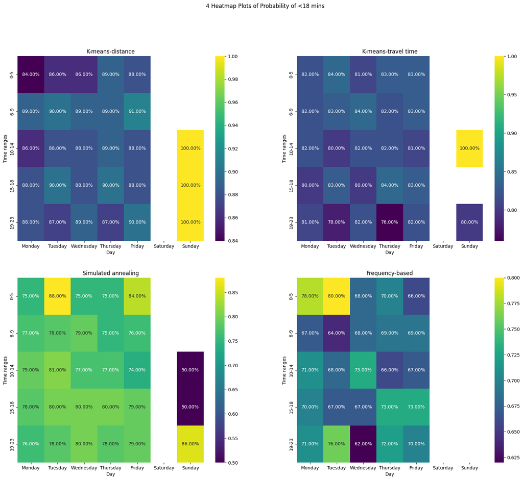

```python
import seaborn as sns
import matplotlib.pyplot as plt
import pandas as pd

dataframes = [results_1, results_2, results_3, results_4]

subplot_titles = ['K-means-distance', 'K-means-travel time', 'Simulated annealing', 'Frequency-based']

# Make the subplots
fig, axes = plt.subplots(2, 2, figsize=(20, 16), subplot_kw={'title': ''})
fig.suptitle('4 Heatmap Plots of Probability of <18 mins')

# Set the day order
day_order = ['Monday', 'Tuesday', 'Wednesday', 'Thursday', 'Friday', 'Saturday', 'Sunday']

# Set the time order
time_range_order = ['0-5', '6-9', '10-14', '15-18', '19-23']

for i, df in enumerate(dataframes):
    ax = axes[i // 2, i % 2]
    ax.set_title(subplot_titles[i])

    df['Time ranges'] = pd.Categorical(df['Time ranges'], categories=time_range_order, ordered=True)

    full_data = pd.DataFrame(index=time_range_order, columns=day_order, dtype=float)
    full_data = full_data.fillna(0)

    for index, row in df.iterrows():
        full_data.at[row['Time ranges'], row['Day']] = float(row['Probability of <18 mins'])

    sns.heatmap(full_data, annot=True, fmt=".2%", cmap='viridis', cbar=True, ax=ax)
    ax.set_xlabel('Day')
    ax.set_ylabel('Time ranges')
plt.savefig('heatmap_data.png', dpi=300)
plt.show()
```

### 6.4 Compare the results from the validation

Finally the results from the validation are plotted in one figure to easily compare the different methods. This plot can also be found in **Dashboard_visuals_set_up.html**.

```python
# Import data for validation
kmeans_dist_val = pd.read_csv('Dashboard_data\Optimization_results\kmeans_dist_validation.csv')
kmeans_time_val = pd.read_excel('Dashboard_data\Optimization_results\kmeans_time_Validation.xlsx')
sa_val = pd.read_csv(r'Dashboard_data\Optimization_results\results11_simulated_annealing.csv')
freq_val = pd.read_csv(r'Dashboard_data\Optimization_results\validation_freq_by_day.csv')
```

```python
# Convert relevant columns to numeric and only keep the weekdays
df_list = [kmeans_dist_val, kmeans_time_val, sa_val, freq_val]

for i in range(len(df_list)):
    if df_list[i] is not None:
        df_list[i] = df_list[i][df_list[i]['Day'].isin(['Monday', 'Tuesday', 'Wednesday', 'Thursday', 'Friday'])]
        df_list[i]['Average Travel Time'] = pd.to_numeric(df_list[i]['Average Travel Time'], errors='coerce')
        df_list[i]['Probability of <18 mins'] = pd.to_numeric(df_list[i]['Probability of <18 mins'], errors='coerce')
```

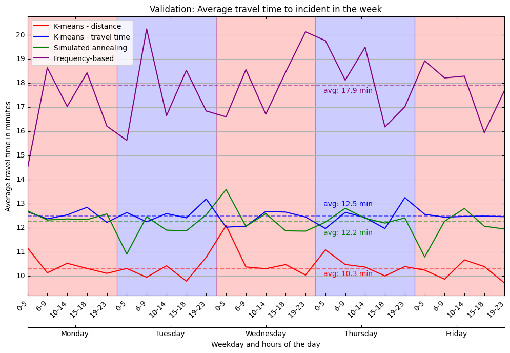

```python
# Set x and various labels
x = np.arange(len(df_list[0]))
colors = ['red', 'blue', 'green', 'purple']
category = ['K-means - distance', 'K-means - travel time', 'Simulated annealing', 'Frequency-based']
y_coor = [10, 12.9, 11.7, 17.6]

# Create figures
fig = plt.figure(figsize=[12,8])
host = host_subplot(111, axes_class=AA.Axes)
plt.subplots_adjust(bottom=0.2)

# Create second x-axis for xticks for day
par1 = host.twiny()
offset = -45
new_fixed_axis = par1.get_grid_helper().new_fixed_axis
par1.axis["bottom"] = new_fixed_axis(loc="bottom",
                                    axes=par1,
                                    offset=(0, offset))

# Plot lines
for i in range(len(df_list)):
    if df_list[i] is not None:
        host.plot(x, df_list[i]['Average Travel Time'] / 60, color=colors[i], label=category[i])

        plt.axhline(np.average(df_list[i]['Average Travel Time'],
                                weights=df_list[i]['Number of incidents']) / 60,
                                linestyle='--', color=colors[i], alpha=0.5)

        plt.annotate(f'avg: {np.average(df_list[i]["Average Travel Time"], weights=df_list[i]["Number of incidents"]) / 60:.1f} min',
                            (14.9, y_coor[i]), color=colors[i])

# Plot colored areas to see the different days
colors = ['red', 'blue', 'red', 'blue', 'red']
for i in range(5):
    host.axvspan(i * 5 - 0.5, i * 5 + 4.5, alpha=0.2, color=colors[i])

# Set right x-ticks for first x-axis
host.set_xlim((0, len(x) - 1))
host.set_xticks(x, labels=df_list[0]['Time ranges'])
plt.setp(host.axis["bottom"].major_ticklabels, rotation=45, ha="right")

# Set right x-ticks and x-label for second x-axis
par1.set_xlim((0, 5))
par1.set_xticks(np.arange(0.5, 5.5), ['Monday', 'Tuesday', 'Wednesday', 'Thursday', 'Friday'])
par1.set_xlabel('Weekday and hours of the day')

# Set yticks
par1.set_yticks(np.arange(10, 21))

# Update layout figure
host.set_ylabel('Average travel time in minutes')
host.grid(axis='y')
plt.legend()
plt.title('Validation: Average travel time to incident in the week');
```

## 7. Results and conclusions

According to the validation results, the **k-means distance** algorithm performs best with an average travel time of only **10.3 minutes**! (See figure in section 6.4.) Secondly comes the simmulated annealing algorithm with a travel time of 12.2 minutes, closely followed by the kmeans travel time algorithm with 12.5 mintues. Lastly is the frequency-based algorithm. Even though it performs worse than the other algorithms, it still managed to achieve an average travel time less than 18 minutes.

This means, according to this validation, that all algorithms satisfy the requirement to have an average travel time of less than 18 minutes.

The main research question for this project was: What are the optimum locations for road inspectors to reach incidents as fast as possible?. The optimum location can be seen in the map in the dashboard: https://rws-group3-48o79awm3zv6cbmgpeaj2d.streamlit.app/ (or watch the short demo. Link given at the beginning of the notebook). Even though the optimal location are given by the k-means distance algorithm, all algorithms satisfy the requirement and can be seen in the dashboard. The different figures shown in the dashboard have been made in the following notebook: **Dashboard_visuals_set_up.html** or the .ipynb version.

In this project there was looked at different traffic scenarios for optimal conditions and peak hour conditions. However, due to time constraints it was not possible to run all algorithms for peak hour conditions, so there are only results for the k-means distance algorithm (see dashboard). It can be concluded that to maintain the same level of service throughout the whole day, more road inspectors are needed during peak hours to maintain the average travel time to an incident of 18 minutes. According to that algorithm, the optimal number of road inspectors increased from 47 to 84 during peak hours.

## 8. Discussion

**What could have been done better?**

1. For the K-means method, the clusters are based on the Euler distance. If the clusters can use the on-road travel distance, the locations of road inspectors could be more optimised. This is the next-step optimising direction of the K-means method.
2. For K-means by travel time method, theoretically minimum travel time of all data in train set should be less 18 minutes, because the travel time criteria is set 18 minutes. However, if we were to continuously iterate to find the location of an Inspector that satisfies this condition, it would require an indefinite number of iterations. To reduce the time required, we have limited the number of iterations, so the final solution may not be the globally optimal solution but rather a locally optimal solution. This can introduce some deviation from the ideal scenario.
3. For the simulated annealing method, the improvement could be achieved by using larger training sets or more realistic clustering centers for incidents/accidents.
4. For the frequency based method, adding more constaint regarding the distance between inspectors is needed.
5. The incident data could be narrowed down more to reduce the running time of the model.
6. The candidate nodes for the inspector location could be defined at the filtering phase. It makes the size of model input smaller.
7. The actual recorded traffic condition could be the model parameter to get more realistic result. The current model uses the minimum or peak hour travel time, in that case the actual traffic of the specific incident is not considered.

**What are the ethical measures that should be looked at?**

1. The data used in the assignment is neutral. That means, there is no indication to reveal or control the behaviour of certain perseon or population segment.
2. The algorithm needs to consider the equity of the road inspector distribution for all the regions. Right now, the Randstad area of Netherlands is very focused on because of the frequency of the incident in that area.

**What is the general reflection based on this project?**

The machine learning is very useful to get the optimum location of the road inspector. It is proved that the machine learning could have a better result rather than the Gaussian distribution approach or any other method. However, it can be seen that the computational cost for this method could be high due to the complexity of the problem. This problem should be handled with a better problem definition and scoping. Furthermore, to increase the accuracy of the model, the machine learning methods could use physical and infrastructure condition for their parameters.

[figure not shown]

Created in Deepnote